# Homework 2

Eva Vincent - emv857

Here is the link to my [GitHub repository](https://github.com/eva-vincent/sds315-HW2).

# Problem 1: Beauty, or not, in the classroom

## Part A

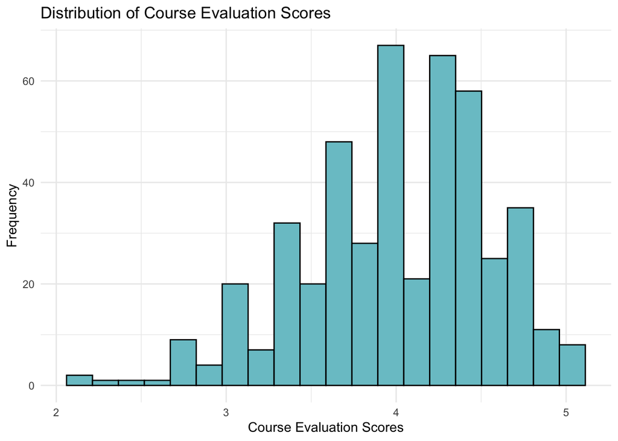

Above is the distribution of the instructor’s average teaching evaluation score for courses in the sample. The distribution is negatively skewed, suggesting that more average scores tend to be larger than the mean.

## Part B

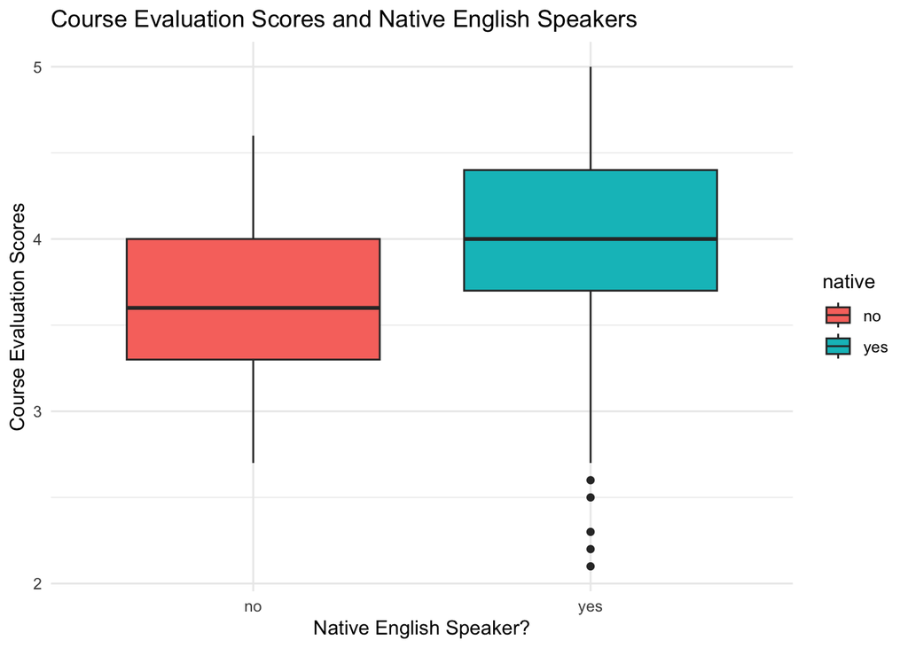

Above are the boxplots for professors’ average course evaluation scores by whether or not they are a native English speaker. The plot suggests that, on average, native English speaking professors have higher evaluations by students.

## Part C

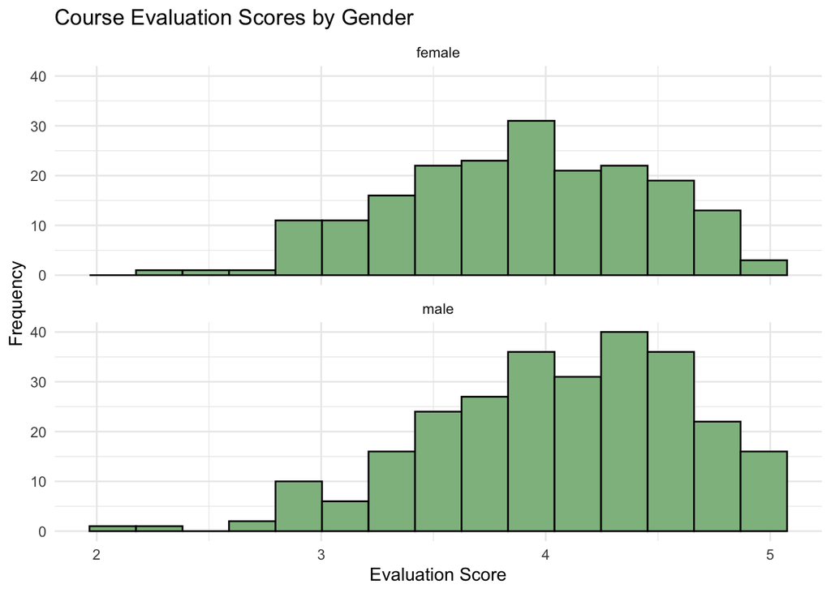

Above are the distributions of average course evaluation scores by gender. The graph shows that male professors’ scores are slightly more negatively skewed than those of the female professors, indicating a greater number of high scores for the male professors.

## Part D

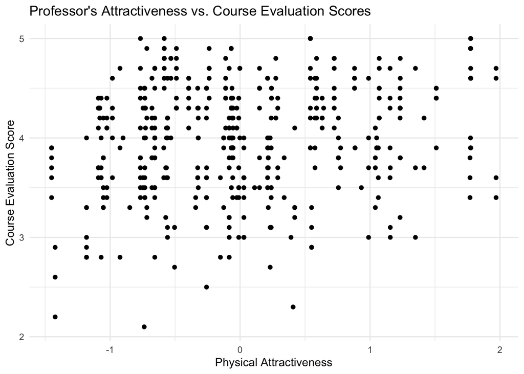

# Problem 2: Bike sharing

## Plot A

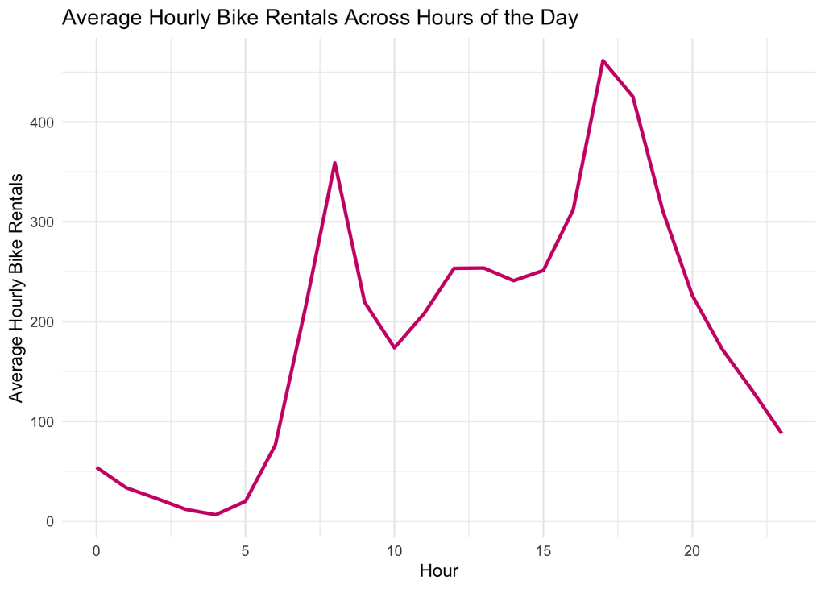

This plot visualizes the average number of hourly bike rentals across all hours of the day. The y-axis represents the average number of all hourly bike rentals while the x-axis represents which hour of the day the average corresponds to. The x-axis is uses 24-hour time. Bike rentals seem to sharply increase around 8 am and 5 pm which might be due to the fact that these are the most common start and end times for working hours. From this plot, we can support the idea that bike rentals have a strong correlation to working hours.

## Plot B

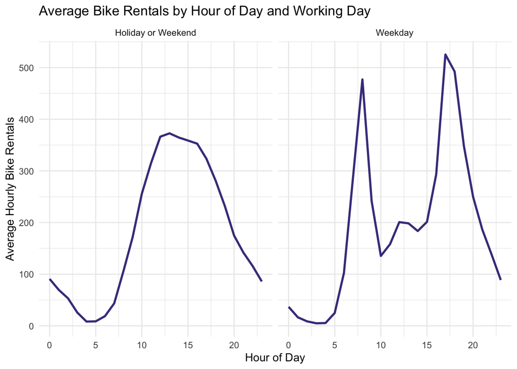

## Plot C

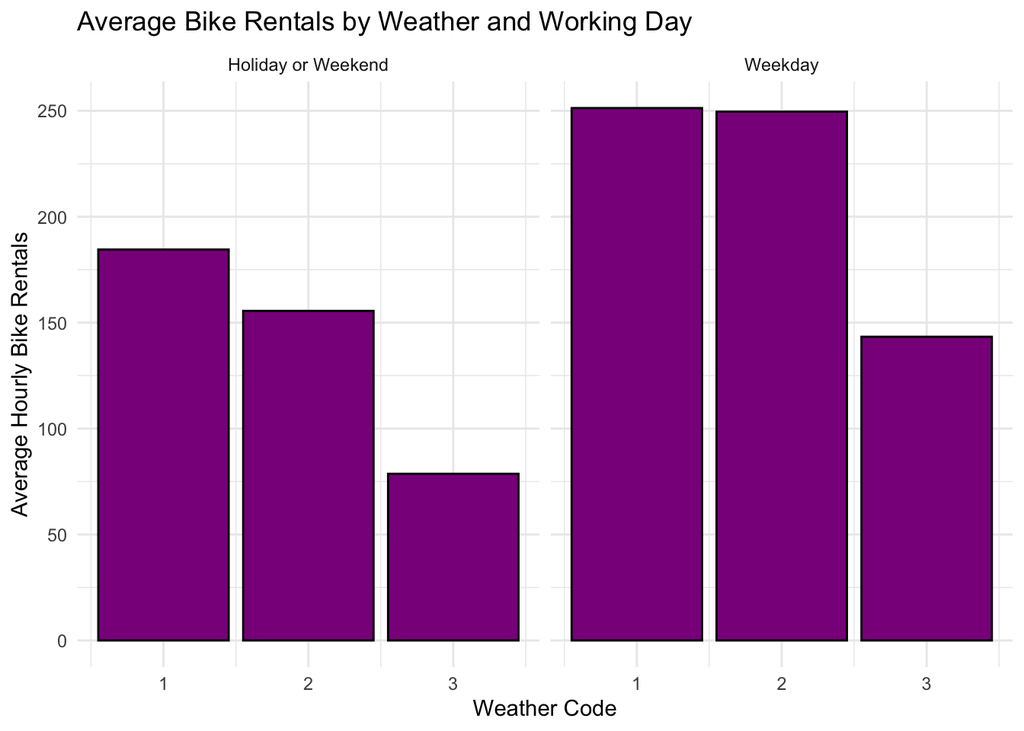

The bar plot above shows the average hourly bike rentals for various weather conditions. Weather code 1 indicates clear, few clouds, and partly cloudy conditions. Weather code 2 indicates mist + cloudy, mist + broken clouds, mist + few clouds, and mist conditions. Weather code 3 indicates light snow, light rain + thunderstorm + scattered clouds, and light rain + scattered clouds conditions. This graph only includes observations taken during the 9 am hour. As weather conditions stray further from clear or cloudy weather, the graph shows that average ridership decreases. This could be a result of perceived risk or a decision to opt for covered transportation like a bus or taxi. In addition, ridership is significantly greater during workdays, but still shows a similar pattern of decreasing as weather conditions worsen. This graph tells us that bike ridership has some relationship to weather although the factor of working days can skew the effect of the weather.

# Problem 3: Capital Metro UT Ridership

## Plot 1

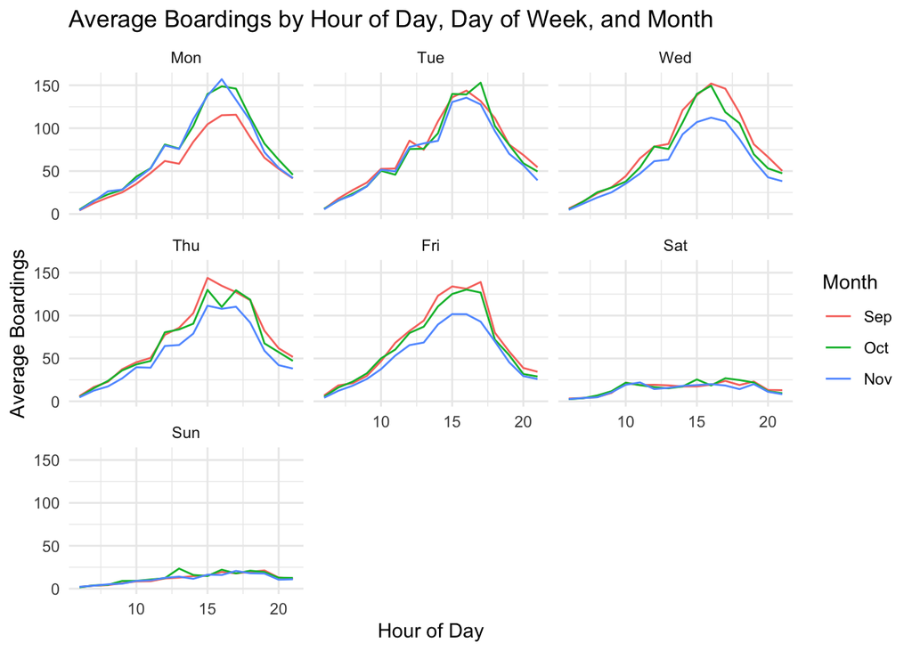

The above plot shows the average number of bus boardings by hour of the day and divided by day of the week. Each facet contains three lines, one for each month. The hour of peak boarding shows similar patterns across weekdays and similar patterns across weekends. The weekday plots show peak boarding times to occur in the evening around 5 pm while weekend plots show no specific peak boarding time. A number of factors could help explain the lower amount of boardings taking place on Mondays in September. I believe comfort with the bus system at the beginning of the year could help explain this lower ridership as many students may need to time to readjust coming back from summer break. I assume that boardings on Wednesday, Thursday, and Friday in November may be lower due to the fall break that takes place every year, and students are not on campus.

## Plot 2

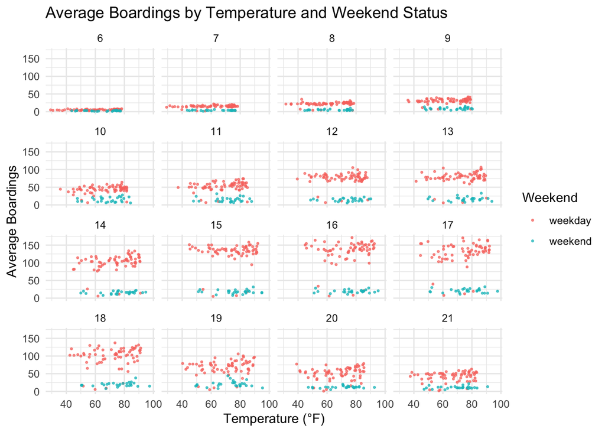

The figure shows the relationship between average boarding and temperature. The graph is faceted by hour, on 24-hour time, and color coded by weekend or weekday. It does not appear that temperature has an effect on the number of UT students riding the bus, evidenced by the lack of an upwards or downwards trend as you move left or right on the graphs.

# Problem 4: Wrangling the Billboard Top 100

## Part A

Top 10 Most Popular Songs by Time on Billboard

| song | performer | count |
| --- | --- | --- |
| Radioactive | Imagine Dragons | 87 |
| Sail | AWOLNATION | 79 |
| Blinding Lights | The Weeknd | 76 |
| I’m Yours | Jason Mraz | 76 |
| How Do I Live | LeAnn Rimes | 69 |
| Counting Stars | OneRepublic | 68 |
| Party Rock Anthem | LMFAO Featuring Lauren Bennett & GoonRock | 68 |
| Foolish Games/You Were Meant For Me | Jewel | 65 |
| Rolling In The Deep | Adele | 65 |
| Before He Cheats | Carrie Underwood | 64 |

The above table shows the top 10 most popular songs by how long they stayed on the Billboard Top 100.

## Part B

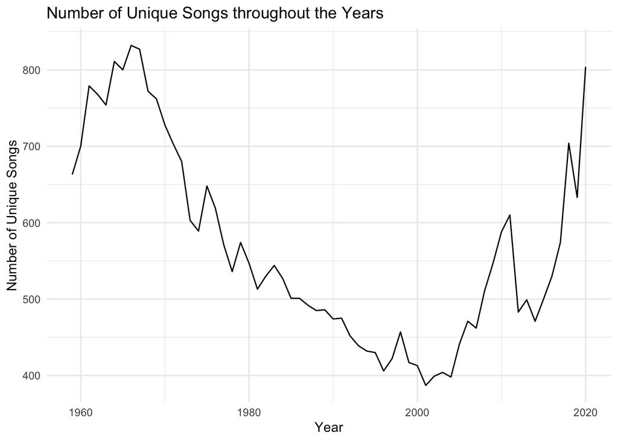

The line graph shows the number of unique songs, songs that only stayed on the Billboard for one week, over the years. The years 1958 and 2021 were not included as they are incomplete. Musical diversity saw a decrease from the years 1965-2000 and didnt dramatically increase until the late 2000s.

## Part C

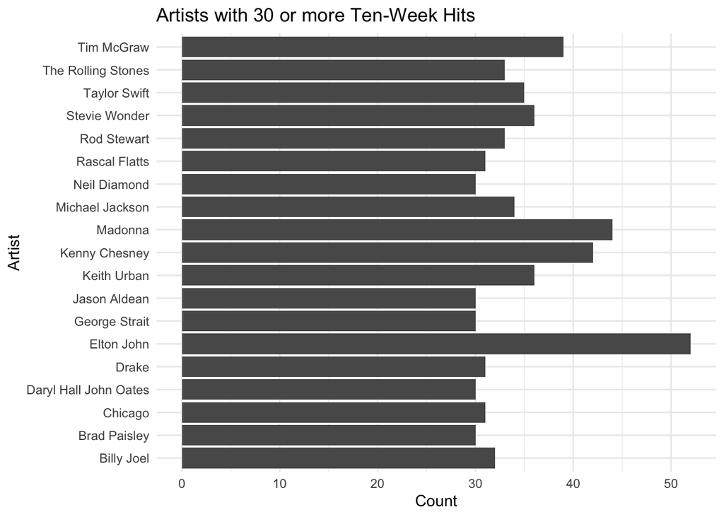

The graph displays the 19 artists who have had 30 or more ten-week hits, songs that stayed on the Billboard Top 100 for 10 or more weeks, and how many of these hits they had.